# 세포라 파이썬 코드 정리

## 라이브러리 로드

```python
# libraries
import numpy as np
import matplotlib.pyplot as plt
import pandas as pd
import matplotlib.font_manager as fm

%matplotlib inline

# 에러 무시 코드
import warnings
warnings.filterwarnings("ignore")
```

```python
import matplotlib
matplotlib.rcParams['axes.unicode_minus'] = False
```

```python
# !pip install matplotlib.Font_manager
# import matplotlib.pyplot as plt
# import matplotlib.font_manager as fm
# from matplotlib import font_manager, rc
# font_path = '/Users/jiyeonglee/Malgun_Gothic.ttf'
# fontprop = fm.FontProperties(fname=font_path, size=18)
# font = fm.FontProperties(fname=font_path).get_name()
# plt.rc('font', family=font)
```

## 데이터 로드

```python
df = pd.read_excel("dataset/masterfile.xlsx")
```

```python
df.head(5)
```

|  | TIMESTAMP | 성별 | 거주지 | 연령대 | 다음 헬스앤뷰티 스토어 중 귀하가 가장 많이 이용하는 곳은 어디입니까? | 헬스앤뷰티만족도 | 이용 만족도 | 가격 | 샘플 | 이벤트 | ... | 기대하는 효과 | 디자인 | 가성비 | 브랜드 가치 | 해외 뷰티 만족도 | 화장푸 성분 | 기대하는 효과.1 | 디자인.1 | 가성비.1 | 브랜드 가치.1 |
| --- | --- | --- | --- | --- | --- | --- | --- | --- | --- | --- | --- | --- | --- | --- | --- | --- | --- | --- | --- | --- | --- |
| 0 | 2020-05-20 13:28:29 | 1 | 2 | 2 | 5 | NaN | 3 | 4 | 2 | 3 | ... | 3 | 3 | 3 | 3 | NaN | 4 | 3 | 3 | 3 | 3 |
| 1 | 2020-05-20 13:28:31 | 1 | 2 | 2 | 5 | NaN | 4 | 3 | 2 | 3 | ... | 3 | 3 | 4 | 3 | NaN | 4 | 5 | 4 | 4 | 4 |
| 2 | 2020-05-20 13:32:07 | 1 | 2 | 2 | 5 | NaN | 3 | 3 | 2 | 3 | ... | 3 | 4 | 4 | 4 | NaN | 3 | 4 | 5 | 2 | 3 |
| 3 | 2020-05-20 13:32:54 | 1 | 2 | 2 | 5 | NaN | 4 | 3 | 2 | 3 | ... | 3 | 2 | 4 | 2 | NaN | 3 | 3 | 4 | 2 | 5 |
| 4 | 2020-05-20 13:34:28 | 1 | 2 | 2 | 5 | NaN | 4 | 4 | 3 | 2 | ... | 4 | 3 | 4 | 3 | NaN | 4 | 4 | 4 | 2 | 4 |

5 rows × 36 columns

# 연령대 시각화

```python
df = pd.read_excel("dataset/masterfile01.xlsx",header=[1])
df = df.iloc[:,:-2]
df_age = pd.DataFrame(df.groupby("연령대").count()["성별"])
df_age.columns = ["수"]
df_age.reset_index(inplace=True)
df_age["연령대"] = ["10대","20대","30대","40대","50대"]
```

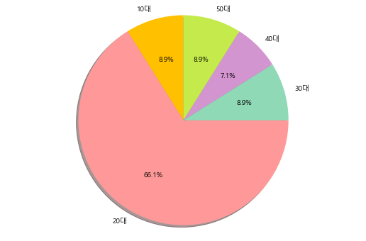

```python
colors = [ '#ffc000','#ff9999', '#8fd9b6', '#d395d0','#C4EB4B']

# Pie chart, where the slices will be ordered and plotted counter-clockwise:
labels = df_age["연령대"]
sizes = df_age["수"]
# explode = (0, 0.1, 0, 0,0)  # only "explode" the 2nd slice (i.e. 'Hogs')

fig1, ax1 = plt.subplots(figsize=(9, 6))
ax1.pie(sizes,  labels=labels, autopct='%1.1f%%', shadow=True, startangle=90, colors=colors)
ax1.axis('equal')  # Equal aspect ratio ensures that pie is drawn as a circle.

plt.show()
```

```python
df = pd.read_excel("dataset/masterfile01.xlsx",header=[1])
df = df.iloc[:,:-2]
df_sat = pd.DataFrame(np.mean(df[['가격', '샘플', '이벤트', '멤버쉽 제도']]))
df_sat.columns = ['만족도']
df_sat
```

|  | 만족도 |
| --- | --- |
| 가격 | 3.303571 |
| 샘플 | 2.500000 |
| 이벤트 | 3.214286 |
| 멤버쉽 제도 | 3.607143 |

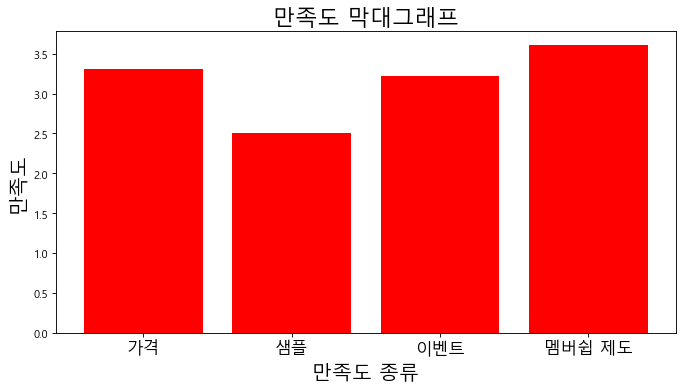

```python
plt.figure(figsize=(10, 5), dpi=80)

plt.bar(df_sat.index, df_sat['만족도'], color="red")

plt.title('만족도 막대그래프', fontsize=20)

plt.xlabel('만족도 종류', fontsize=18)

plt.ylabel('만족도', fontsize=18)

plt.xticks(df_sat.index, fontsize=15)

plt.show()
```

## 연령대에 따른 서비스 만족도 시각화

#### 연령대 범주 설정

1. 10대
2. 20-30대
3. 40-50대

```python
df1 = df[[ '연령대','화장품 진열 방식', '직원 서비스', '브랜드가 다양한 점','뷰티 서비스']]
df1.head(5)
```

|  | 연령대 | 화장품 진열 방식 | 직원 서비스 | 브랜드가 다양한 점 | 뷰티 서비스 |
| --- | --- | --- | --- | --- | --- |
| 0 | 2 | 4 | 3 | 4 | 3 |
| 1 | 2 | 3 | 4 | 4 | 3 |
| 2 | 2 | 3 | 3 | 3 | 3 |
| 3 | 2 | 5 | 5 | 5 | 4 |
| 4 | 2 | 4 | 4 | 4 | 4 |

```python
df1.groupby("연령대").mean()
```

| 연령대 | 화장품 진열 방식 | 직원 서비스 | 브랜드가 다양한 점 | 뷰티 서비스 |
| --- | --- | --- | --- | --- |
| 1 | 4.000000 | 3.00000 | 3.400000 | 3.400000 |
| 2 | 3.243243 | 3.27027 | 3.675676 | 3.243243 |
| 3 | 2.400000 | 2.00000 | 2.600000 | 2.600000 |
| 4 | 3.250000 | 3.25000 | 3.250000 | 3.250000 |
| 5 | 3.400000 | 3.60000 | 3.800000 | 3.400000 |

```python
for i in (range(len(df1))):
    if df1["연령대"].loc[i] <= 3 and df1["연령대"].loc[i] > 1  :
        df1["연령대"].loc[i] = "20-30대"
    elif df1["연령대"].loc[i] == 1:
        df1["연령대"].loc[i] = "10대"
    else:
        df1["연령대"].loc[i] = "40-50대"
```

```python
df1.groupby("연령대").mean()
```

| 연령대 | 화장품 진열 방식 | 직원 서비스 | 브랜드가 다양한 점 | 뷰티 서비스 |
| --- | --- | --- | --- | --- |
| 10대 | 4.000000 | 3.000000 | 3.400000 | 3.400000 |
| 20-30대 | 3.142857 | 3.119048 | 3.547619 | 3.166667 |
| 40-50대 | 3.333333 | 3.444444 | 3.555556 | 3.333333 |

[figure not shown]

```python
plt.figure(figsize=(9, 6), dpi=80)

# 위에서 구한 테이블을 df1에 저장
df1 = df1.groupby("연령대").mean()

# set width of bars
barWidth = 0.2

# set heights of bars
bars1 = df1.iloc[0,:]
bars2 = df1.iloc[1,:]
bars3 = df1.iloc[2,:]

# Set position of bar on X axis
r1 = np.arange(len(bars1))
r2 = [x + barWidth for x in r1]
r3 = [x + barWidth for x in r2]

# Make the plot
plt.bar(r1, bars1, color='#2BC5EA', width=barWidth, edgecolor='white', label='10대')
plt.bar(r2, bars2, color='#EA4B2B', width=barWidth, edgecolor='white', label='20~30대')
plt.bar(r3, bars3, color='#88A726', width=barWidth, edgecolor='white', label='40~50대')

# Add xticks on the middle of the group bars
plt.ylabel('연령대',fontweight='normal',fontsize=20, labelpad=30)
plt.yticks(fontweight='normal',fontsize=10)
plt.xlabel('만족도',fontweight='normal',fontsize=20, labelpad=30)
plt.xticks([r + barWidth for r in range(len(bars1))], ['화장품 진열 방식', '직원 서비스', '브랜드가 다양한 점', '뷰티 서비스'])
# plt.title("asfas")

# Create legend & Show graphic
plt.legend(loc=1, prop={'size': 10})

plt.rc('font', family='AppleGothic')
plt.rcParams['axes.unicode_minus']= False

plt.show()
```

# TRY!!!!!!!!!!!!!!!!!!!!!!!!!!!!!!!!!!!!!!!!!!!!!!!!!!!!!!!!!!!!!!!!!!!!!!!1

- 연령대 별 혹은 다른 변수별로 묶어서 그래프에 나타내기

```python
df2 = df[['연령대', ' PB상품 구매 경험',' 미디어, 옥외광고', '유튜버 또는 SNS ','다른 사람들과 이야기']]
df2.head(6)
```

|  | 연령대 | PB상품 구매 경험 | 미디어, 옥외광고 | 유튜버 또는 SNS | 다른 사람들과 이야기 |
| --- | --- | --- | --- | --- | --- |
| 0 | 2 | 1 | 4 | 4 | 4 |
| 1 | 2 | 2 | 2 | 3 | 3 |
| 2 | 2 | 1 | 2 | 1 | 1 |
| 3 | 2 | 4 | 3 | 5 | 4 |
| 4 | 2 | 2 | 2 | 3 | 4 |
| 5 | 3 | 1 | 2 | 2 | 1 |

```python
df2.groupby("연령대").mean()
```

| 연령대 | PB상품 구매 경험 | 미디어, 옥외광고 | 유튜버 또는 SNS | 다른 사람들과 이야기 |
| --- | --- | --- | --- | --- |
| 1 | 2.200000 | 2.400000 | 2.800000 | 2.200000 |
| 2 | 1.540541 | 2.675676 | 3.162162 | 2.837838 |
| 3 | 1.000000 | 2.200000 | 2.000000 | 1.200000 |
| 4 | 1.000000 | 1.000000 | 1.000000 | 1.250000 |
| 5 | 2.200000 | 1.800000 | 2.200000 | 2.000000 |

```python
for i in (range(len(df2))):
    if df2["연령대"].loc[i] <= 3 and df2["연령대"].loc[i] > 1  :
        df2["연령대"].loc[i] = "20-30대"
    elif df2["연령대"].loc[i] == 1:
        df2["연령대"].loc[i] = "10대"
    else:
        df2["연령대"].loc[i] = "40-50대"
```

```python
df2.groupby("연령대").mean()
```

| 연령대 | PB상품 구매 경험 | 미디어, 옥외광고 | 유튜버 또는 SNS | 다른 사람들과 이야기 |
| --- | --- | --- | --- | --- |
| 10대 | 2.200000 | 2.400000 | 2.800000 | 2.200000 |
| 20-30대 | 1.476190 | 2.619048 | 3.023810 | 2.642857 |
| 40-50대 | 1.666667 | 1.444444 | 1.666667 | 1.666667 |

```
findfont: Font family ['AppleGothic'] not found. Falling back to DejaVu Sans.
findfont: Font family ['AppleGothic'] not found. Falling back to DejaVu Sans.
```

[figure not shown]

```python
plt.figure(figsize=(9, 6), dpi=80)

# 위에서 구한 테이블을 df1에 저장
df2 = df2.groupby("연령대").mean()

# set width of bars
barWidth = 0.3

# set heights of bars
bars1 = df2.iloc[0,:]
bars2 = df2.iloc[1,:]
bars3 = df2.iloc[2,:]

# Set position of bar on X axis
r1 = np.arange(len(bars1))
r2 = [x + barWidth for x in r1]
r3 = [x + barWidth for x in r2]

# Make the plot
plt.bar(r1, bars1, color='#2BC5EA', width=barWidth, edgecolor='white', label='10대')
plt.bar(r2, bars2, color='#EA4B2B', width=barWidth, edgecolor='white', label='20~30대')
plt.bar(r3, bars3, color='#88A726', width=barWidth, edgecolor='white', label='40~50대')

# Add xticks on the middle of the group bars
plt.ylabel('연령대',fontweight='normal',fontsize=20, labelpad=30)
plt.yticks(fontweight='normal',fontsize=10)
plt.xlabel('인식도',fontweight='normal',fontsize=20, labelpad=30)
plt.xticks([r + barWidth for r in range(len(bars1))], [' PB상품 구매 경험',' 미디어, 옥외광고', '유튜버 또는 SNS ','다른 사람들과 이야기'])
# plt.title("asfas")

# Create legend & Show graphic
plt.legend(loc=1, prop={'size': 10})

plt.rc('font', family='Malgun Gothic')
plt.rcParams['axes.unicode_minus']= False

plt.show()
```

# 세포라 만족도를 이용한 분석 예시

### 친구에게 추천해준다고 말하는 사람들은 어떤 만족도가 가장 높았을까?

친구에게 추천해준다고 말하는 사람들은 지인을 통한 마케팅이 이루어 진다고 말할수있다. 따라서, 친구에게 추천해준다고 말하는 사람들과 그렇지 않은 사람들은 어떤 서비스에 의해서 이런 결정을 하게 된건지 알아보고, 추후 해당 서비스를 증대 시킴으로 친구들에게 추천해준다고 말하는 사람들의 비율을 더욱 효과적으로 늘릴수 있을것으로 기대해 본다.

##### 머신러닝 기법이랑 어떤 분석 느낌인지는 다음에 자세히 설명드릴게요 이런 식으로 분석 가능하다 정도만 봐보세요!

```python
df = pd.read_excel("dataset/masterfile.xlsx")
```

```python
# df = pd.read_excel("/Users/jiyeonglee/masterfile.xlsx")
df3 = df[[ '화장품 진열 방식', '직원 서비스', '브랜드가 다양한 점','뷰티 서비스',' 친구나 동료에게 추천 할 것']]
df3.head(5)
```

|  | 화장품 진열 방식 | 직원 서비스 | 브랜드가 다양한 점 | 뷰티 서비스 | 친구나 동료에게 추천 할 것 |
| --- | --- | --- | --- | --- | --- |
| 0 | 4 | 3 | 4 | 3 | 3 |
| 1 | 3 | 4 | 4 | 3 | 3 |
| 2 | 3 | 3 | 3 | 3 | 3 |
| 3 | 5 | 5 | 5 | 4 | 5 |
| 4 | 4 | 4 | 4 | 4 | 4 |

```python
from sklearn.ensemble import RandomForestClassifier
clf = RandomForestClassifier(max_depth=2, random_state=0)
clf.fit(df3.iloc[:,:-1], df3.iloc[:,-1])
```

```python
df4 = df3.iloc[:2,:-1]
df4.iloc[0] = [1,2,5,4]
df4.iloc[1] = [3,2,4,1]
df4
```

```python
clf.predict(df4)
```

```
array([4, 2])
```

```python
clf.feature_importances_
```

```
array([0.25376103, 0.19096035, 0.13776305, 0.41751556])
```

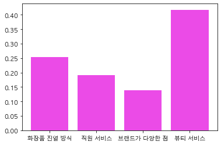

```python
# Make a random dataset:
height = clf.feature_importances_
bars = df3.columns[:-1]
y_pos = np.arange(len(bars))

# Create bars
plt.bar(y_pos, height,color='#EB4BE7')

# Create names on the x-axis
plt.xticks(y_pos, bars)

# Show graphic
plt.show()
```

# 분석예시 설명:

%%%% 주의:::: 데이터가 너무 적고 현재 훈련시키고 검증을 통하지 않은 상태임.... 단순히 이런 느낌으로 분석 할 수 있다 정도만 생각하면 될거같습니다!!!!!!!!!!!!!!!!!!!!!!!!!!!!!!

```python
#국내 화장품 브랜드와 해외 화장품 브랜드 가치를 어떻게 생각하는 사람이 세포라의 브랜드 다양성에는 어떠한 만족도를 나타냈다
```

# 상관관계 분석

```python
df = pd.read_excel("dataset/masterfile01.xlsx",header=[1])
df = df.iloc[:,:-2]
```

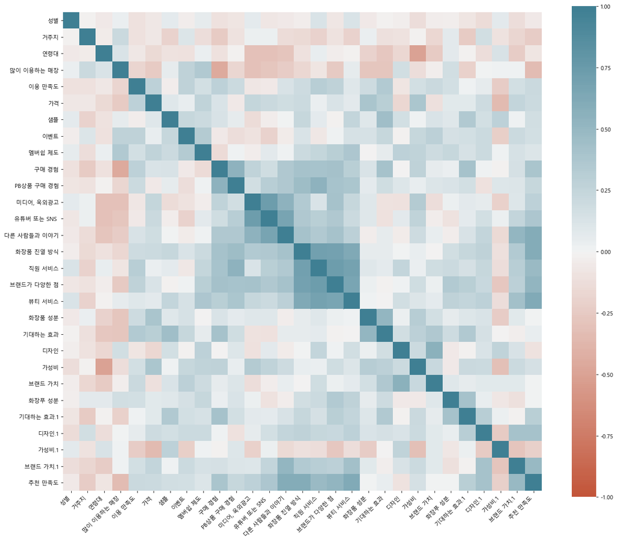

```python
import seaborn as sns
plt.figure(figsize=(19, 16), dpi=80)

corr = df.corr()

ax = sns.heatmap(
    corr,
    vmin=-1, vmax=1, center=0,
    cmap=sns.diverging_palette(20, 220, n=200),
    square=True
)
ax.set_xticklabels(
    ax.get_xticklabels(),
    rotation=45,
    horizontalalignment='right'
);

plt.rc('font', family='Malgun Gothic')
plt.show()
```

## 상관관계 분석 예제 01

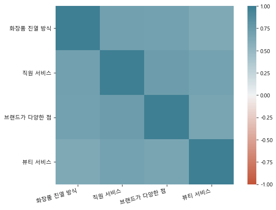

```python
plt.figure(figsize=(9, 6), dpi=80)

corr = df[['화장품 진열 방식', '직원 서비스', '브랜드가 다양한 점','뷰티 서비스']].corr()

ax = sns.heatmap(
    corr,
    vmin=-1, vmax=1, center=0,
    cmap=sns.diverging_palette(20, 220, n=200),
    square=True
)
ax.set_xticklabels(
    ax.get_xticklabels(),
    rotation=15,
    horizontalalignment='right'
);

plt.rc('font', family='Malgun Gothic')
plt.show()
```

# 데이터 분석 : 국내 해외 만족도 차이 확인

20대가 아닌 연령대

```python
df = pd.read_excel("/Users/jiyeonglee/masterfile.xlsx")
df = df.iloc[:,:-2]
df = df.iloc[:,18:28]
```

```python
df.describe()
```

|  | 세포라 만족도 | 화장품 진열 방식 | 직원 서비스 | 브랜드가 다양한 점 | 친구나 동료에게 추천 할 것 | 뷰티 서비스 | 국내 뷰티 만족도 | 화장품 성분 | 기대하는 효과 | 디자인 |
| --- | --- | --- | --- | --- | --- | --- | --- | --- | --- | --- |
| count | 0.0 | 56.000000 | 56.000000 | 56.000000 | 56.000000 | 56.000000 | 0.0 | 56.000000 | 56.000000 | 56.000000 |
| mean | NaN | 3.250000 | 3.160714 | 3.535714 | 3.321429 | 3.214286 | NaN | 3.267857 | 3.089286 | 3.196429 |
| std | NaN | 0.939052 | 0.949197 | 1.026278 | 0.916657 | 0.846690 | NaN | 0.725912 | 0.668153 | 0.922834 |
| min | NaN | 1.000000 | 1.000000 | 1.000000 | 1.000000 | 1.000000 | NaN | 2.000000 | 2.000000 | 1.000000 |
| 25% | NaN | 3.000000 | 3.000000 | 3.000000 | 3.000000 | 3.000000 | NaN | 3.000000 | 3.000000 | 3.000000 |
| 50% | NaN | 3.000000 | 3.000000 | 4.000000 | 3.000000 | 3.000000 | NaN | 3.000000 | 3.000000 | 3.000000 |
| 75% | NaN | 4.000000 | 4.000000 | 4.000000 | 4.000000 | 4.000000 | NaN | 4.000000 | 4.000000 | 4.000000 |
| max | NaN | 5.000000 | 5.000000 | 5.000000 | 5.000000 | 5.000000 | NaN | 5.000000 | 4.000000 | 5.000000 |

```python
df = pd.read_excel("/Users/jiyeonglee/masterfile01.xlsx",header=[ 1])
df = df[df["연령대"]!=2]
df = df.iloc[:,:-2]
df = df.iloc[:,18:28]
df_not20 = df.describe()[["가성비","가성비.1"]]
df_not20_price = df["가성비"]
df_not20_price1 = df["가성비.1"]
```

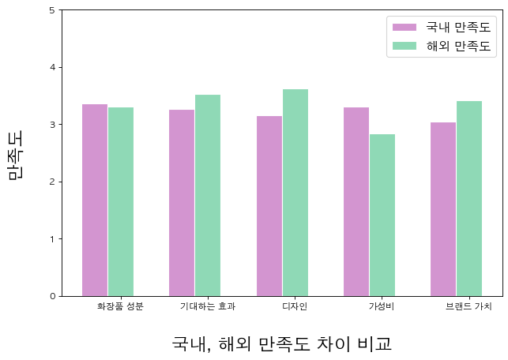

```python
plt.figure(figsize=(9, 6), dpi=80)

# set width of bars
barWidth = 0.3

# set heights of bars
bars1 = df.describe().iloc[1,:][:5]
bars2 = df.describe().iloc[1,:][5:]

# Set position of bar on X axis
r1 = np.arange(len(bars1))
r2 = [x + barWidth for x in r1]
#colors = ['#ff9999', '#ffc000', '#8fd9b6', '#d395d0']
# Make the plot
plt.bar(r1, bars1, color='#d395d0', width=barWidth, edgecolor='white', label='국내 만족도')
plt.bar(r2, bars2, color='#8fd9b6', width=barWidth, edgecolor='white', label='해외 만족도')

# Add xticks on the middle of the group bars
plt.ylabel('만족도',fontweight='normal',fontsize=20, labelpad=30)
plt.yticks(fontweight='normal',fontsize=10)
plt.xlabel('국내, 해외 만족도 차이 비교',fontweight='normal',fontsize=20, labelpad=30)
plt.xticks([r + barWidth for r in range(len(bars1))], df.describe().iloc[1,:][:5].index)
# plt.title("asfas")

# Create legend & Show graphic
plt.legend(loc=1, prop={'size': 14})

#plt.rc('font', family='Malgun Gothic')
plt.rc('font', family='AppleGothic')

plt.ylim([0, 5])

plt.show()
```

20대가 느끼는 만족도

```python
df = pd.read_excel("/Users/jiyeonglee/masterfile01.xlsx",header=[ 1])
df = df[df["연령대"]==2]
df = df.iloc[:,:-2]
df = df.iloc[:,18:28]
df_20 = df.describe()[["가성비","가성비.1"]]
df_20_price = df["가성비"]
df_20_price1 = df["가성비.1"]
df.describe()
```

|  | 화장품 성분 | 기대하는 효과 | 디자인 | 가성비 | 브랜드 가치 | 화장품 성분.1 | 기대하는 효과.1 | 디자인.1 | 가성비.1 | 브랜드 가치.1 |
| --- | --- | --- | --- | --- | --- | --- | --- | --- | --- | --- |
| count | 37.000000 | 37.00000 | 37.000000 | 37.000000 | 37.000000 | 37.000000 | 37.000000 | 37.000000 | 37.000000 | 37.000000 |
| mean | 3.216216 | 3.00000 | 3.216216 | 3.945946 | 3.216216 | 3.081081 | 3.351351 | 3.810811 | 2.216216 | 4.000000 |
| std | 0.712396 | 0.62361 | 0.886163 | 0.621197 | 0.672274 | 0.759326 | 0.633167 | 0.775952 | 1.003747 | 0.881917 |
| min | 2.000000 | 2.00000 | 2.000000 | 3.000000 | 2.000000 | 1.000000 | 2.000000 | 2.000000 | 1.000000 | 1.000000 |
| 25% | 3.000000 | 3.00000 | 3.000000 | 4.000000 | 3.000000 | 3.000000 | 3.000000 | 3.000000 | 2.000000 | 4.000000 |
| 50% | 3.000000 | 3.00000 | 3.000000 | 4.000000 | 3.000000 | 3.000000 | 3.000000 | 4.000000 | 2.000000 | 4.000000 |
| 75% | 4.000000 | 3.00000 | 4.000000 | 4.000000 | 4.000000 | 4.000000 | 4.000000 | 4.000000 | 3.000000 | 5.000000 |
| max | 5.000000 | 4.00000 | 5.000000 | 5.000000 | 5.000000 | 4.000000 | 5.000000 | 5.000000 | 5.000000 | 5.000000 |

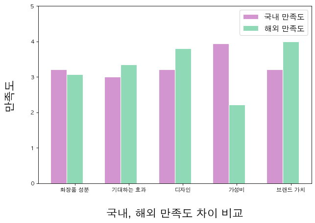

```python
plt.figure(figsize=(9, 6), dpi=80)

# set width of bars
barWidth = 0.3

# set heights of bars
bars1 = df.describe().iloc[1,:][:5]
bars2 = df.describe().iloc[1,:][5:]

# Set position of bar on X axis
r1 = np.arange(len(bars1))
r2 = [x + barWidth for x in r1]
#colors = ['#ff9999', '#ffc000', '#8fd9b6', '#d395d0']
# Make the plot
plt.bar(r1, bars1, color='#d395d0', width=barWidth, edgecolor='white', label='국내 만족도')
plt.bar(r2, bars2, color='#8fd9b6', width=barWidth, edgecolor='white', label='해외 만족도')

# Add xticks on the middle of the group bars
plt.ylabel('만족도',fontweight='normal',fontsize=20, labelpad=30)
plt.yticks(fontweight='normal',fontsize=10)
plt.xlabel('국내, 해외 만족도 차이 비교',fontweight='normal',fontsize=20, labelpad=30)
plt.xticks([r + barWidth for r in range(len(bars1))], df.describe().iloc[1,:][:5].index)
# plt.title("asfas")

# Create legend & Show graphic
plt.legend(loc=1, prop={'size': 14})

plt.rc('font', family='Malgun Gothic')
# plt.rc('font', family='AppleGothic')

plt.ylim([0, 5])

plt.show()
```

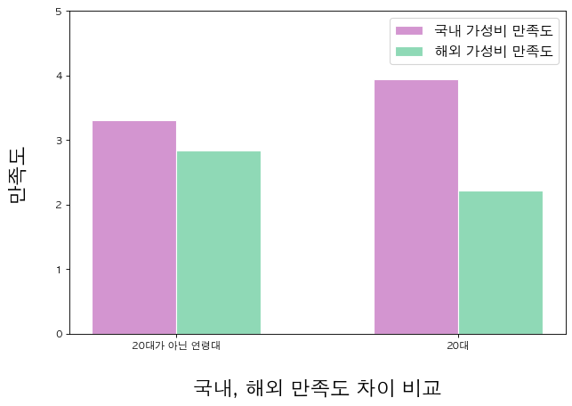

```python
plt.figure(figsize=(9, 6), dpi=80)

# set width of bars
barWidth = 0.3

# set heights of bars
bars1 = [df_not20.iloc[1,:][0],df_20.iloc[1,:][0]]
bars2 = [df_not20.iloc[1,:][1],df_20.iloc[1,:][1]]

# Set position of bar on X axis
r1 = np.arange(len(bars1))
r2 = [x + barWidth for x in r1]
#colors = ['#ff9999', '#ffc000', '#d395d0', '#d395d0']
# Make the plot
plt.bar(r1, bars1, color='#d395d0', width=barWidth, edgecolor='white', label='국내 가성비 만족도')
plt.bar(r2, bars2, color='#8fd9b6', width=barWidth, edgecolor='white', label='해외 가성비 만족도')

# Add xticks on the middle of the group bars
plt.ylabel('만족도',fontweight='normal',fontsize=20, labelpad=30)
plt.yticks(fontweight='normal',fontsize=10)
plt.xlabel('국내, 해외 만족도 차이 비교',fontweight='normal',fontsize=20, labelpad=30)
plt.xticks([r + barWidth/2 for r in range(len(bars1))], ["20대가 아닌 연령대","20대"])
# plt.title("asfas")

# Create legend & Show graphic
plt.legend(loc=1, prop={'size': 14})

#plt.rc('font', family='Malgun Gothic')
plt.rc('font', family='AppleGothic')

plt.ylim([0, 5])

plt.show()
```

```python
from scipy import stats
# 20대가 아닌 연령대가 느끼는 가성비 만족도 차이
t_test1 = stats.ttest_ind(df_not20_price, df_not20_price1)
print(t_test1)

# 결론: 차이 없음
```

```
Ttest_indResult(statistic=1.6371154689952478, pvalue=0.11031974400651397)
```

```python
# 20대가 느끼는 가성비 만족도 차이
t_test1 = stats.ttest_ind(df_20_price, df_20_price1)
print(t_test1)

# 결론 차이 있음
```

```
Ttest_indResult(statistic=8.91337623249849, pvalue=3.02789223165467e-13)
```

## 통계 분석 예제) 가설 검정

가설 검정 :Hypothesis Test (Two Sample T-Test)

- 두 개의 표본의 평균을 비교하여 해당 평균에 차이가 있는지 확인하는 검정
- 귀무가설: 차이가 없다.
- 대립가설: 차이가 있다.
- P-value를 확인하여, 유의수준 (보통 95%, 0.05 사용) 보다 작은 경우, 귀무가설을 기각하며 대립가설을 채택

```python
from scipy import stats

t_test1 = stats.ttest_ind(df["화장품 성분"], df["화장품 성분.1"])
print(t_test1)
```

```
Ttest_indResult(statistic=0.7771916402262602, pvalue=0.43871391730797626)
```

통계분석 가설검정 결론: P-value가 0.05 보다 큼으로, 95% 신뢰 수준에 의한 국내의 화장품 성분과 해외의 화장품 성분에 대한 만족도에는 통계적으로 유의미한 차이가 있다고 보기 힘들다.

### TRY: 기대하는 효과 / 디자인 / 가성비 / 브랜드 가치 변수에 적용해보고 통계적으로 유의미한 차이가 있는지 확인해보기